# STA141A Project

## Session 10: Data integration

Session 10 Data

```r
get_trail_data <- function(session_id, trail_id){
  spikes <- session[[session_id]]$spks[[trail_id]]
  if (any(is.na(spikes))){
    disp("value missing")
  }

  #trail_tibble <- as_tibble(spikes) %>% set_names(binename) %>%  add_column("brain_area" = session[[session_id]]$brain_area ) %>% group_by(brain_area) %>% summarize( "sum_spikes" =across(everything(),sum),.groups = "drop")
  trail_tibble <- tibble("neuron_spike" = rowSums(spikes))  %>%  add_column("brain_area" = session[[session_id]]$brain_area ) %>% group_by(brain_area) %>% summarize( region_sum_spike = sum(neuron_spike), region_count = n(),region_mean_spike = mean(neuron_spike))
  trail_tibble  = trail_tibble%>% add_column("trail_id" = trail_id) %>% add_column("contrast_left"= session[[session_id]]$contrast_left[trail_id]) %>% add_column("contrast_right"= session[[session_id]]$contrast_right[trail_id]) %>% add_column("feedback_type"= session[[session_id]]$feedback_type[trail_id])
  trail_tibble
}


trail_tibble_1_2 <- get_trail_data(1,2)
trail_tibble_1_2
```

```
## # A tibble: 8 × 8
##   brain_area region_sum_spike region_count region_mean_spike trail_id
##   <chr>                 <dbl>        <int>             <dbl>    <dbl>
## 1 ACA                      64          109             0.587        2
## 2 CA3                     116           68             1.71         2
## 3 DG                       53           34             1.56         2
## 4 LS                      190          139             1.37         2
## 5 MOs                      88          113             0.779        2
## 6 SUB                     146           75             1.95         2
## 7 VISp                    294          178             1.65         2
## 8 root                     12           18             0.667        2
## # ℹ 3 more variables: contrast_left <dbl>, contrast_right <dbl>,
## #   feedback_type <dbl>
```

```r
trail_tibble_1_1 <- get_trail_data(1,1)
trail_tibble_1_1
```

```
## # A tibble: 8 × 8
##   brain_area region_sum_spike region_count region_mean_spike trail_id
##   <chr>                 <dbl>        <int>             <dbl>    <dbl>
## 1 ACA                     138          109             1.27         1
## 2 CA3                     104           68             1.53         1
## 3 DG                       79           34             2.32         1
## 4 LS                      269          139             1.94         1
## 5 MOs                     106          113             0.938        1
## 6 SUB                     156           75             2.08         1
## 7 VISp                    300          178             1.69         1
## 8 root                      9           18             0.5          1
## # ℹ 3 more variables: contrast_left <dbl>, contrast_right <dbl>,
## #   feedback_type <dbl>
```

After defining the function, the code calls get_trail_data with session_id = 1 and trail_id = 2, storing the result in a variable named trail_tibble_1_2. This variable contains the processed data for trial 2 in session 1.

Data Integration

```r
get_session_data <- function(session_id){
  n_trail <- length(session[[session_id]]$spks)
  trail_list <- list()
  for (trail_id in 1:n_trail){
    trail_tibble <- get_trail_data(session_id,trail_id)
    trail_list[[trail_id]] <- trail_tibble
  }
  session_tibble <- do.call(rbind, trail_list)
  session_tibble <- session_tibble %>% add_column("mouse_name" = session[[session_id]]$mouse_name) %>% add_column("date_exp" = session[[session_id]]$date_exp) %>% add_column("session_id" = session_id)
  session_tibble
}


session_list = list()
for (session_id in 1: 18){
  session_list[[session_id]] <- get_session_data(session_id)
}
full_tibble <- do.call(rbind, session_list)
full_tibble$success <- full_tibble$feedback_type == 1
full_tibble$success <- as.numeric(full_tibble$success)
full_tibble$contrast_diff <- abs(full_tibble$contrast_left-full_tibble$contrast_right)
```

```r
binename <- paste0("bin", as.character(1:40))

get_trail_functional_data <- function(session_id, trail_id){
  spikes <- session[[session_id]]$spks[[trail_id]]
  if (any(is.na(spikes))){
    disp("value missing")
  }

  trail_bin_average <- matrix(colMeans(spikes), nrow = 1)
  colnames(trail_bin_average) <- binename
  trail_tibble  = as_tibble(trail_bin_average)%>% add_column("trail_id" = trail_id) %>% add_column("contrast_left"= session[[session_id]]$contrast_left[trail_id]) %>% add_column("contrast_right"= session[[session_id]]$contrast_right[trail_id]) %>% add_column("feedback_type"= session[[session_id]]$feedback_type[trail_id])

  trail_tibble
}
get_session_functional_data <- function(session_id){
  n_trail <- length(session[[session_id]]$spks)
  trail_list <- list()
  for (trail_id in 1:n_trail){
    trail_tibble <- get_trail_functional_data(session_id,trail_id)
    trail_list[[trail_id]] <- trail_tibble
  }
  session_tibble <- as_tibble(do.call(rbind, trail_list))
  session_tibble <- session_tibble %>% add_column("mouse_name" = session[[session_id]]$mouse_name) %>% add_column("date_exp" = session[[session_id]]$date_exp) %>% add_column("session_id" = session_id)
  session_tibble
}
session_list = list()
for (session_id in 1: 18){
  session_list[[session_id]] <- get_session_functional_data(session_id)
}
full_functional_tibble <- as_tibble(do.call(rbind, session_list))
full_functional_tibble$session_id <- as.factor(full_functional_tibble$session_id )
full_functional_tibble$contrast_diff <- abs(full_functional_tibble$contrast_left-full_functional_tibble$contrast_right)

full_functional_tibble$success <- full_functional_tibble$feedback_type == 1
full_functional_tibble$success <- as.numeric(full_functional_tibble$success)
```

```r
#the number of neuron’s in each session
full_tibble %>% filter (trail_id==1) %>% group_by(session_id) %>% summarise(sum(region_count))
```

```
## # A tibble: 18 × 2
##    session_id `sum(region_count)`
##         <int>               <int>
##  1          1                 734
##  2          2                1070
##  3          3                 619
##  4          4                1769
##  5          5                1077
##  6          6                1169
##  7          7                 584
##  8          8                1157
##  9          9                 788
## 10         10                1172
## 11         11                 857
## 12         12                 698
## 13         13                 983
## 14         14                 756
## 15         15                 743
## 16         16                 474
## 17         17                 565
## 18         18                1090
```

```r
# the number brain area of each session
full_tibble %>% group_by(session_id) %>% summarise(unique_area = n_distinct(brain_area))
```

```
## # A tibble: 18 × 2
##    session_id unique_area
##         <int>       <int>
##  1          1           8
##  2          2           5
##  3          3          11
##  4          4          11
##  5          5          10
##  6          6           5
##  7          7           8
##  8          8          15
##  9          9          12
## 10         10          13
## 11         11           6
## 12         12          12
## 13         13          15
## 14         14          10
## 15         15           8
## 16         16           6
## 17         17           6
## 18         18          10
```

```r
#Average Spike rate over each session
average_spike <-full_tibble %>% group_by( session_id, trail_id) %>% mutate(mean_spike = sum(region_sum_spike)/sum(region_count))
average_spike %>% group_by(session_id) %>% summarise(mean_session_spike = mean(mean_spike))
```

```
## # A tibble: 18 × 2
##    session_id mean_session_spike
##         <int>              <dbl>
##  1          1              1.54
##  2          2              1.27
##  3          3              2.23
##  4          4              0.842
##  5          5              1.12
##  6          6              0.663
##  7          7              1.42
##  8          8              1.66
##  9          9              1.59
## 10         10              1.19
## 11         11              1.25
## 12         12              1.66
## 13         13              2.46
## 14         14              1.01
## 15         15              1.46
## 16         16              1.05
## 17         17              1.17
## 18         18              1.10
```

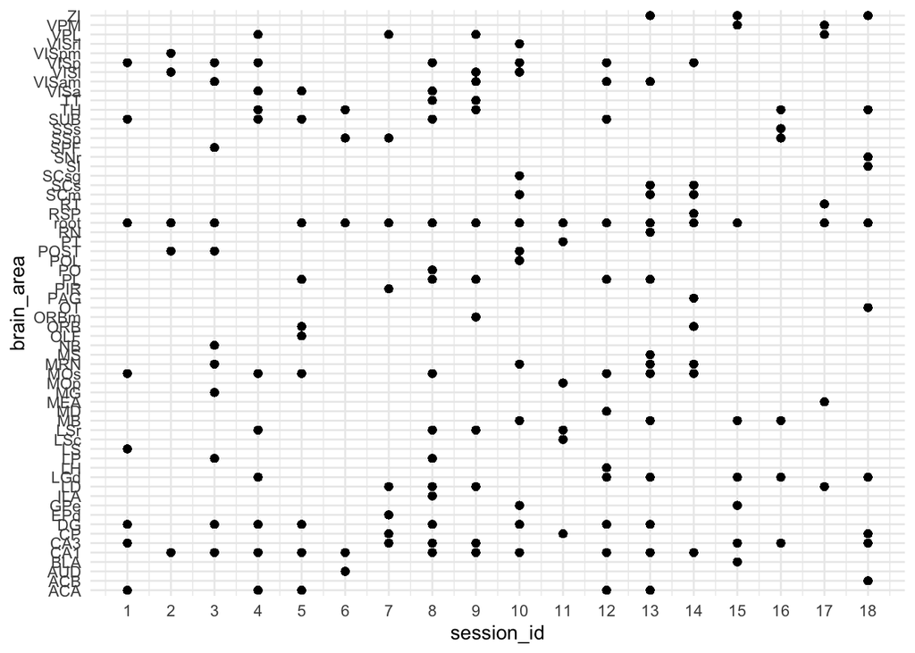

```r
# Brain areas with neurons recorded in each session
ggplot(full_tibble, aes(x =session_id , y = brain_area)) +
  geom_point() +
  labs(x = "session_id" , y ="brain_area") +
  scale_x_continuous(breaks = unique(full_tibble$session_id)) +
  theme_minimal()
```

```r
full_functional_tibble %>% group_by(session_id) %>% summarize(success_rate = mean(success, na.rm = TRUE))
```

```
## # A tibble: 18 × 2
##    session_id success_rate
##    <fct>             <dbl>
##  1 1                 0.605
##  2 2                 0.633
##  3 3                 0.662
##  4 4                 0.667
##  5 5                 0.661
##  6 6                 0.741
##  7 7                 0.671
##  8 8                 0.644
##  9 9                 0.685
## 10 10                0.620
## 11 11                0.795
## 12 12                0.738
## 13 13                0.797
## 14 14                0.694
## 15 15                0.765
## 16 16                0.718
## 17 17                0.830
## 18 18                0.806
```

```r
full_functional_tibble %>% group_by(mouse_name) %>% summarize(success_rate = mean(success, na.rm = TRUE))
```

```
## # A tibble: 4 × 2
##   mouse_name success_rate
##   <chr>             <dbl>
## 1 Cori              0.639
## 2 Forssmann         0.687
## 3 Hench             0.684
## 4 Lederberg         0.761
```

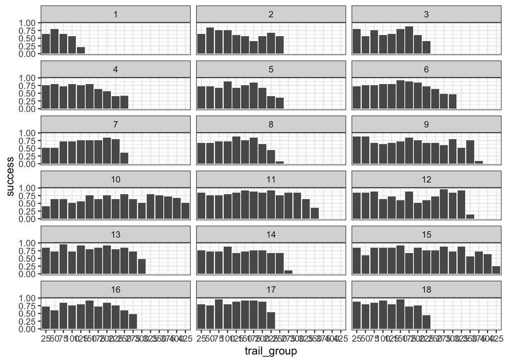

```r
#Visualize success rate change over time (trail)
full_functional_tibble$trail_group = cut(full_functional_tibble$trail_id, breaks = seq(0, max(full_functional_tibble$trail_id), by = 25),include.lowest = TRUE)
levels(full_functional_tibble$trail_group) <- seq(0, max(full_functional_tibble$trail_id), by = 25)[2:18]
success_rate <- aggregate(success ~ session_id + trail_group, data = full_functional_tibble, FUN = function(x) mean(x) )
ggplot(success_rate, aes(x = trail_group, y = success)) +
  geom_bar(stat = "identity", position = "dodge") +
  facet_wrap(~session_id, ncol=3) +
      theme_bw()
```

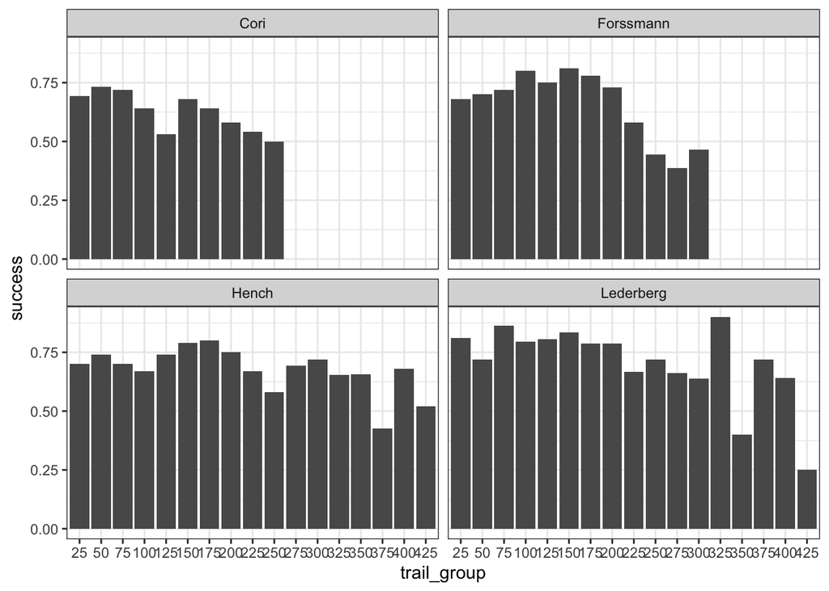

```r
#Visualize success rate change over time (individual mouse)
success_rate <- aggregate(success ~ mouse_name + trail_group, data = full_functional_tibble, FUN = function(x) mean(x) )
ggplot(success_rate, aes(x = trail_group, y = success)) +
  geom_bar(stat = "identity", position = "dodge") +
  facet_wrap(~mouse_name) +
      theme_bw()
```

### Visualize the change of overall neuron spike rate over time

The `average_spike` is the number of spikes within each number bin divided total number of neurons for each trail.

```r
col_names <-names(full_functional_tibble)
region_sum_subset <- col_names[grep("^region_sum", col_names)]
region_mean_subset <- col_names[grep("^region_mean", col_names)]


# average_spike <- full_tibble %>% group_by( session_id,trail_id) %>% summarise(mean_spike = mean(region_mean_spike))
average_spike <- full_tibble %>% group_by( session_id,trail_id) %>% summarise(mean_spike = sum(region_sum_spike)/sum(region_count))
average_spike$mouse_name <- full_functional_tibble$mouse_name
average_spike$contrast_diff <- full_functional_tibble$contrast_diff
average_spike$success <- full_functional_tibble$success
```

The change of overall neuron spike rate for each session

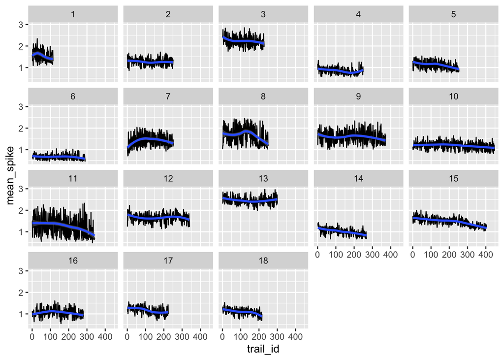

```r
ggplot(average_spike, aes(x = trail_id, y = mean_spike)) +
  geom_line()+
  geom_smooth(method = "loess")+  # Fit a smooth spline

  facet_wrap(~session_id)
```

The change of overall neuron spike rate for each mouse

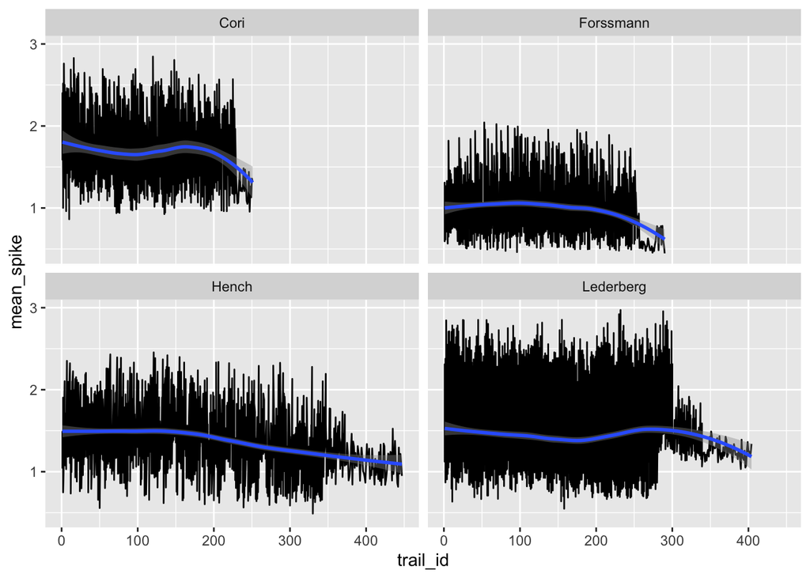

```r
ggplot(average_spike, aes(x = trail_id, y = mean_spike)) +
  geom_line()+
  geom_smooth(method = "loess")+  # Fit a smooth spline

  facet_wrap(~mouse_name)
```

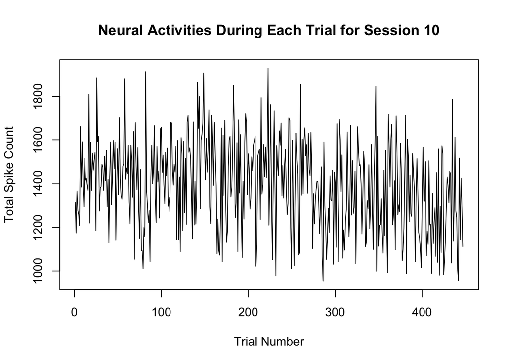

```r
spike_trains_session_1 <- session[[10]]$spks

# Initialize a vector to store the total spike counts across all neurons for each trial
total_spikes_per_trial <- numeric(length(spike_trains_session_1))

# Loop through each trial
for (i in 1:length(spike_trains_session_1)) {
  # Sum the spike counts across all neurons for the current trial
  total_spikes_per_trial[i] <- sum(spike_trains_session_1[[i]])
}

# Plot the total spike counts against the trial numbers
plot(1:length(total_spikes_per_trial), total_spikes_per_trial,
     type = "l", xlab = "Trial Number", ylab = "Total Spike Count",
     main = "Neural Activities During Each Trial for Session 10")
```

## Predictive Modelling

Feedback Type vs Decision

```r
n_obs = length(session[[10]]$feedback_type)

dat = tibble(
    feedback_type = as.factor(session[[10]]$feedback_type),
    decision = rep('name', n_obs),
    avg_spikes = rep(0, n_obs)
)

for (i in 1:n_obs){
    # decision
    if (session[[10]]$contrast_left[i] > session[[10]]$contrast_right[i]){
        dat$decision[i] = '1'
    } else if (session[[10]]$contrast_left[i] < session[[10]]$contrast_right[i]){
        dat$decision[i] = '2'
    } else if (session[[10]]$contrast_left[i] == session[[10]]$contrast_right[i]
               & session[[10]]$contrast_left[i] == 0){
        dat$decision[i] = '3'
    } else{
        dat$decision[i] = '4'
    }

    # avg_spks
    spks.trial = session[[10]]$spks[[i]]
    total.spikes = apply(spks.trial, 1, sum)
    dat$avg_spikes[i] = mean(total.spikes)
}

dat$decision = as.factor(dat$decision)
summary(dat)
```

```
##  feedback_type decision   avg_spikes
##  -1:170        1:179    Min.   :0.814
##  1 :277        2:122    1st Qu.:1.059
##                3:113    Median :1.191
##                4: 33    Mean   :1.188
##                         3rd Qu.:1.327
##                         Max.   :1.646
```

‘1’: If the contrast of the left stimulus is greater than the contrast of the right stimulus. ‘2’: If the contrast of the right stimulus is greater than the contrast of the left stimulus. ‘3’: If both left and right contrasts are zero. ‘4’: If both left and right contrasts are equal but non-zero.

```r
set.seed(101)
sample <- sample.int(n = n_obs, size = floor(.8 * n_obs), replace = F)
train <- dat[sample, ]
test  <- dat[-sample, ]

fit1 <- glm(feedback_type~., data = train, family="binomial")
summary(fit1)
```

```
##
## Call:
## glm(formula = feedback_type ~ ., family = "binomial", data = train)
##
## Coefficients:
##             Estimate Std. Error z value Pr(>|z|)
## (Intercept)  -2.6881     0.8156  -3.296 0.000981 ***
## decision2    -1.0033     0.2923  -3.433 0.000597 ***
## decision3    -0.3784     0.2936  -1.289 0.197431
## decision4    -1.9848     0.4704  -4.219 2.45e-05 ***
## avg_spikes    3.1155     0.6923   4.500 6.78e-06 ***
## ---
## Signif. codes:  0 '***' 0.001 '**' 0.01 '*' 0.05 '.' 0.1 ' ' 1
##
## (Dispersion parameter for binomial family taken to be 1)
##
##     Null deviance: 476.37  on 356  degrees of freedom
## Residual deviance: 436.91  on 352  degrees of freedom
## AIC: 446.91
##
## Number of Fisher Scoring iterations: 4
```

```r
pred1 <- predict(fit1, test %>% select(-feedback_type), type = 'response')
prediction1 <- factor(pred1 > 0.5, labels = c('-1', '1'))
mean(prediction1 != test$feedback_type)
```

```
## [1] 0.4111111
```

a summary of the logistic regression model fitted to the training data and the misclassification rate on the test data, which indicates the model’s performance.

Confusion Matrix for the Model

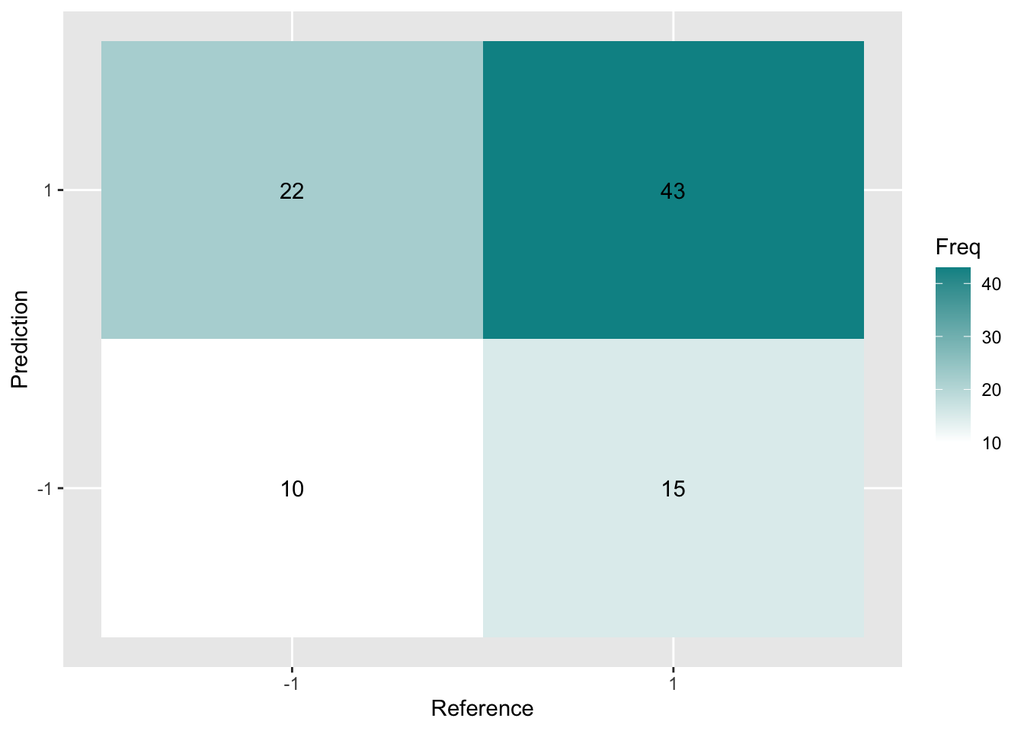

```r
cm <- confusionMatrix(prediction1, test$feedback_type, dnn = c("Prediction", "Reference"))

plt <- as.data.frame(cm$table)

ggplot(plt, aes(Reference, Prediction, fill= Freq)) +
        geom_tile() + geom_text(aes(label=Freq)) +
        scale_fill_gradient(low="white", high="#009194") +
        labs(x = "Reference",y = "Prediction") +
        scale_x_discrete(labels=c("-1","1")) +
        scale_y_discrete(labels=c("-1","1"))
```

a confusion matrix plot visualizing the performance of the model, where the x-axis represents the actual feedback types, the y-axis represents the predicted feedback types, and the color intensity represents the frequency of predictions.

The color intensity within each cell indicates the frequency or count of instances where the model predicted a specific feedback type (y-axis) given the actual feedback type (x-axis).

Off-diagonal cells represent incorrect predictions, where the predicted feedback type does not match the actual feedback type.

Abundance of 1, 1.

Bias of the model

```r
prediction0 = factor(rep('1', nrow(test)), levels = c('1', '-1'))
mean(prediction0 != test$feedback_type)
```

```
## [1] 0.3555556
```

the misclassification rate for the baseline prediction, which provides a benchmark for assessing the performance of the model. If the misclassification rate of the model is lower than that of the baseline prediction, it indicates that the model performs better than simply predicting ‘1’ for all instances.

Confusion Matrix Prediction0

```r
cm <- confusionMatrix(prediction0, test$feedback_type, dnn = c("Prediction", "Reference"))
```

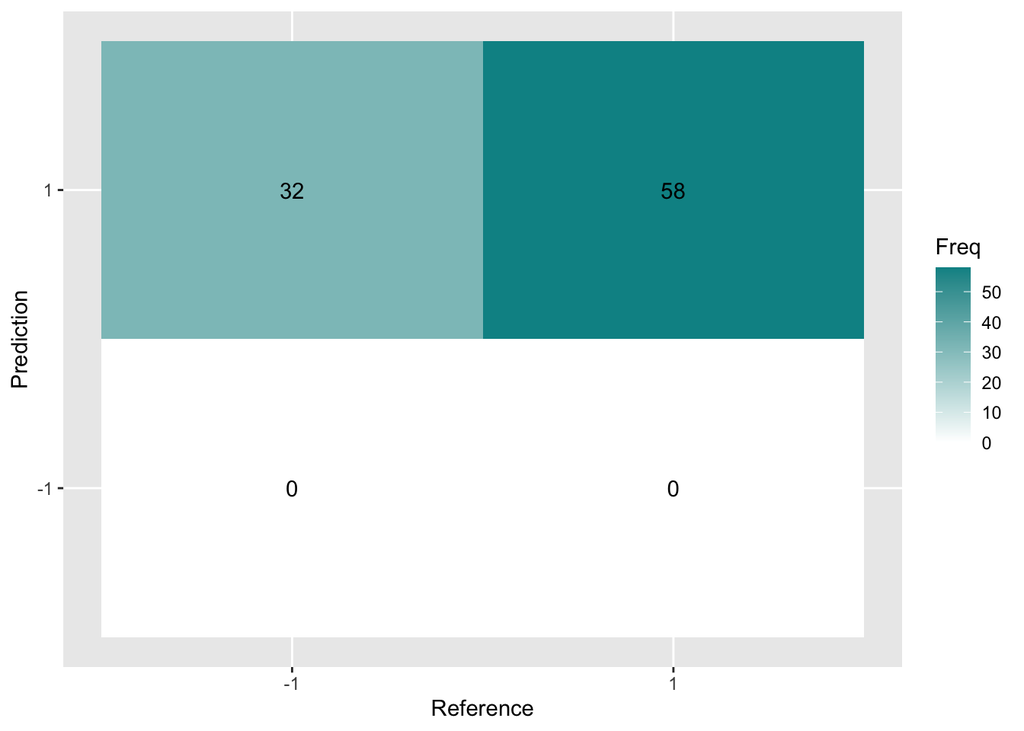

```r
plt <- as.data.frame(cm$table)

ggplot(plt, aes(Reference, Prediction, fill= Freq)) +
        geom_tile() + geom_text(aes(label=Freq)) +
        scale_fill_gradient(low="white", high="#009194") +
        labs(x = "Reference",y = "Prediction") +
        scale_x_discrete(labels=c("-1","1")) +
        scale_y_discrete(labels=c("-1","1"))
```

a confusion matrix plot visualizing the performance of the baseline prediction, where the x-axis represents the actual feedback types, the y-axis represents the predicted feedback types, and the color intensity represents the frequency of predictions.

```r
table(session[[10]]$brain_area)
```

```
##
##   CA1    DG   GPe    MB   MRN   POL  POST  root   SCm  SCsg  VISl  VISp VISrl
##    76    73    63   275    72   154    41    36    23    19    99   105   136
```

```r
average_spike_area<-function(i.t,this_session){
  spk.trial = this_session$spks[[i.t]]
  area= this_session$brain_area
  spk.count=apply(spk.trial,1,sum)
  spk.average.tapply=tapply(spk.count, area, mean)
  return(spk.average.tapply)
}

n_area = length(unique(session[[10]]$brain_area))
spk_area = matrix(rep(0, n_obs * n_area), n_obs, n_area)
for (i in 1:n_obs){
    spk_area[i,] = average_spike_area(i, session[[10]])
}

spk_area = as_tibble(spk_area)
colnames(spk_area)= unique(session[[10]]$brain_area)
dat1 = bind_cols(dat, spk_area) %>% select(-avg_spikes)
head(dat1)
```

```
## # A tibble: 6 × 15
##   feedback_type decision    MB  VISp   SCm  SCsg  POST    DG   MRN   CA1  VISl
##   <fct>         <fct>    <dbl> <dbl> <dbl> <dbl> <dbl> <dbl> <dbl> <dbl> <dbl>
## 1 -1            2        0.816 0.836 0.730  1.57 0.833  1.31 0.927  1.83 1.65
## 2 -1            2        0.658 0.699 0.460  1.29 0.889  1.12 0.951  3.64 0.609
## 3 -1            2        0.855 0.932 0.794  1.74 0.764  1.07 0.976  2.03 0.913
## 4 -1            2        0.908 0.932 0.762  1.30 0.958  1.40 0.634  2.25 0.826
## 5 -1            2        0.816 0.712 0.698  1.58 0.708  1.38 0.732  1.25 0.739
## 6 1             2        0.592 0.726 0.635  1.47 0.819  1.23 1.07   1.67 0.826
## # ℹ 4 more variables: POL <dbl>, root <dbl>, GPe <dbl>, VISrl <dbl>
```

Second Model

```r
set.seed(101)
sample <- sample.int(n = n_obs, size = floor(.8 * n_obs), replace = F)
train <- dat1[sample, ]
test  <- dat1[-sample, ]

fit2 <- glm(feedback_type~., data = train, family="binomial")
summary(fit2)
```

```
##
## Call:
## glm(formula = feedback_type ~ ., family = "binomial", data = train)
##
## Coefficients:
##             Estimate Std. Error z value Pr(>|z|)
## (Intercept)  -4.5254     1.4244  -3.177  0.00149 **
## decision2    -1.1115     0.3414  -3.256  0.00113 **
## decision3    -0.2953     0.3228  -0.915  0.36031
## decision4    -2.2296     0.5261  -4.238 2.26e-05 ***
## MB           -0.2395     0.8448  -0.284  0.77676
## VISp         -1.6197     0.8567  -1.891  0.05867 .
## SCm           2.3996     0.8335   2.879  0.00399 **
## SCsg          1.2937     0.7299   1.773  0.07630 .
## POST          1.7708     0.7182   2.466  0.01367 *
## DG           -0.1436     0.8528  -0.168  0.86627
## MRN           1.2280     0.5962   2.059  0.03945 *
## CA1          -0.1151     0.2361  -0.488  0.62578
## VISl         -0.6011     0.3274  -1.836  0.06638 .
## POL           0.1962     0.2259   0.869  0.38506
## root          1.1045     0.7901   1.398  0.16213
## GPe          -0.6716     0.7688  -0.874  0.38238
## VISrl        -0.4653     1.6476  -0.282  0.77763
## ---
## Signif. codes:  0 '***' 0.001 '**' 0.01 '*' 0.05 '.' 0.1 ' ' 1
##
## (Dispersion parameter for binomial family taken to be 1)
##
##     Null deviance: 476.37  on 356  degrees of freedom
## Residual deviance: 404.84  on 340  degrees of freedom
## AIC: 438.84
##
## Number of Fisher Scoring iterations: 4
```

```r
pred2 <- predict(fit2, test %>% select(-feedback_type), type = 'response')
prediction2 <- factor(pred2 > 0.5, labels = c('-1', '1'))
mean(prediction2 != test$feedback_type)
```

```
## [1] 0.3555556
```

This code fits a logistic regression model (fit2) to predict the feedback type based on the features in the training data (train) after incorporating the average spike count for each brain area in each trial. a summary of the logistic regression model fitted to the training data and the misclassification rate on the test data, which indicates the performance of the model after incorporating the average spike count for each brain area.

Model 2 Confusion Matrix

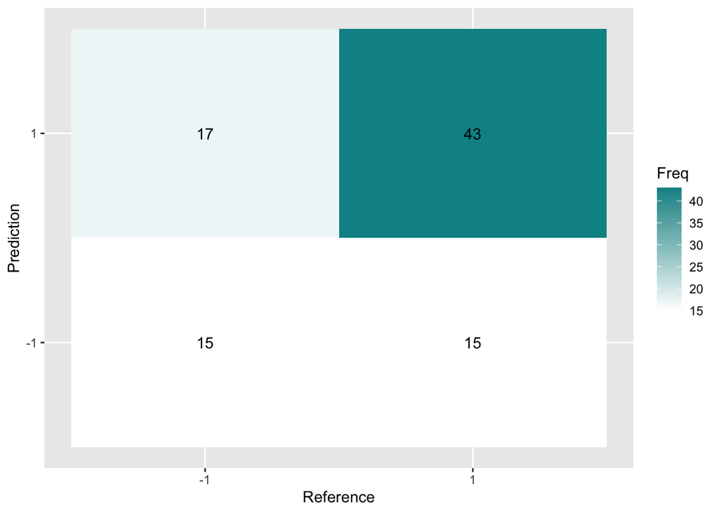

```r
cm <- confusionMatrix(prediction2, test$feedback_type, dnn = c("Prediction", "Reference"))

plt <- as.data.frame(cm$table)

ggplot(plt, aes(Reference, Prediction, fill= Freq)) +
        geom_tile() + geom_text(aes(label=Freq)) +
        scale_fill_gradient(low="white", high="#009194") +
        labs(x = "Reference",y = "Prediction") +
        scale_x_discrete(labels=c("-1","1")) +
        scale_y_discrete(labels=c("-1","1"))
```

This code generates a confusion matrix plot to visualize the performance of the logistic regression model (fit2) after incorporating the average spike count for each brain area.

a confusion matrix plot visualizing the performance of the logistic regression model after incorporating the average spike count for each brain area, where the x-axis represents the actual feedback types, the y-axis represents the predicted feedback types, and the color intensity represents the frequency of predictions.

Which Model is Better

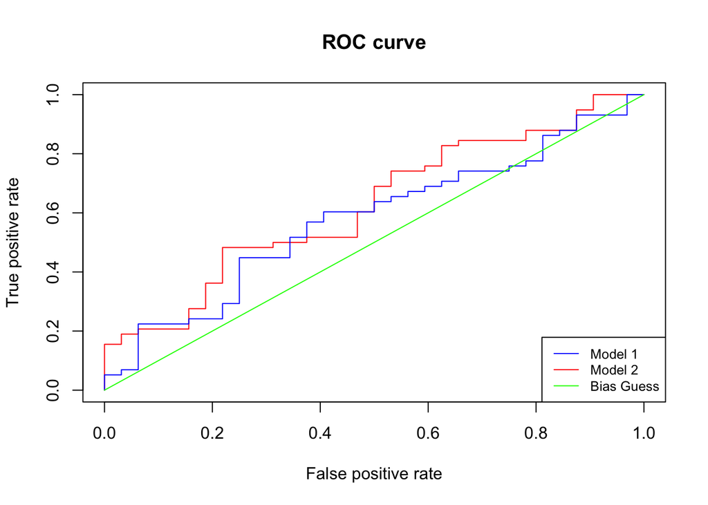

```r
# Model 1
pr = prediction(pred1, test$feedback_type)
prf <- performance(pr, measure = "tpr", x.measure = "fpr")
auc <- performance(pr, measure = "auc")
auc <- auc@y.values[[1]]

# Model 2
pr = prediction(pred2, test$feedback_type)
prf2 <- performance(pr, measure = "tpr", x.measure = "fpr")
auc2 <- performance(pr, measure = "auc")
auc2 <- auc2@y.values[[1]]

# Bias Guess
pred0 = pred1 * 0 + 1
pr = prediction(pred0, test$feedback_type)
prf0 <- performance(pr, measure = "tpr", x.measure = "fpr")
auc0 <- performance(pr, measure = "auc")
auc0 <- auc0@y.values[[1]]

plot(prf2, ,col = 'red', main = 'ROC curve')
plot(prf, add = TRUE, col = 'blue')
plot(prf0, add = TRUE, col = 'green')
legend("bottomright", legend=c("Model 1", "Model 2", "Bias Guess"), col=c("blue", "red", 'green'), lty=1:1,
       cex=0.8)
```

```r
print(c(auc, auc2, auc0))
```

```
## [1] 0.5770474 0.6228448 0.5000000
```